# Lindenmayer Systems and Turtle Graphics

Mr. Worley

2026 Mar 23

# Green Bush

This green bush displays familiar organic branching, but its precise angles and lines belie its computational rendering.

```
Angle = 30°
Start = A
Rules:
  A > A[+A][-A]B
  B > [--B]A
Number of recursions = 7
```

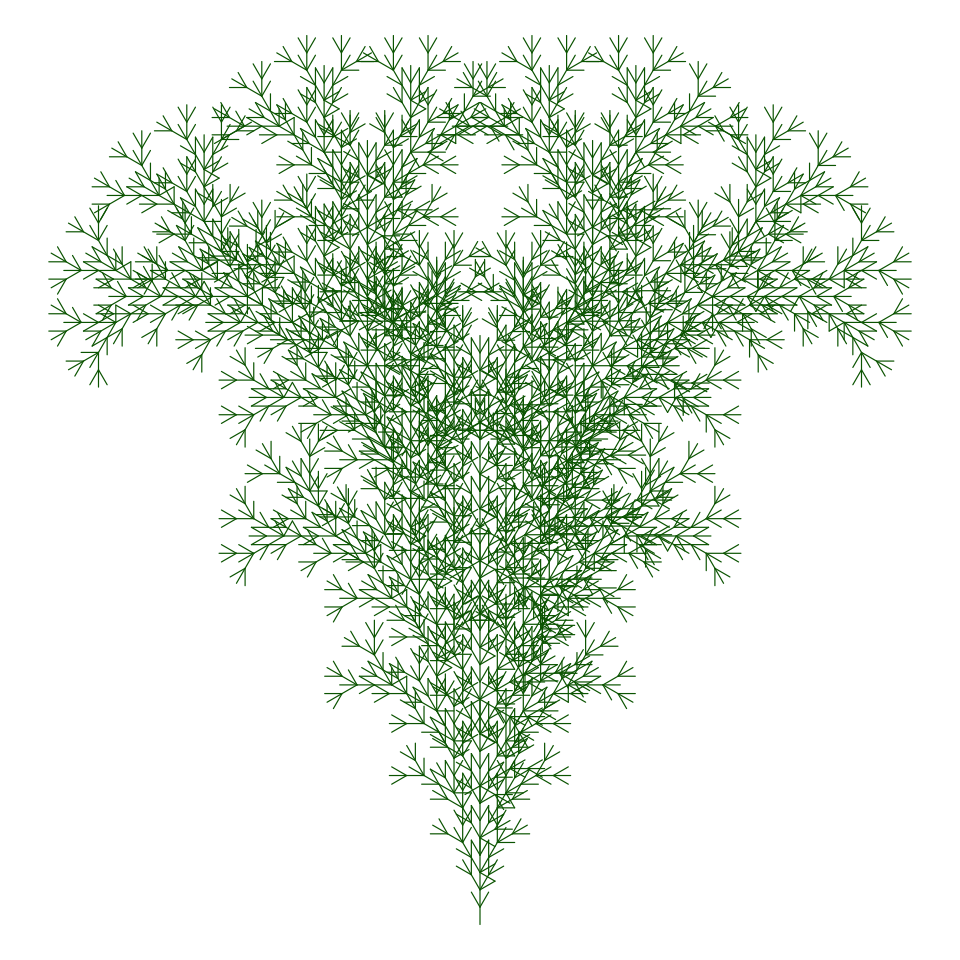

# Alien City

The bees escaped Earth’s limits and evolved into a highly technological society organized into fractal hexagonal arrays.

```
Angle = 60°
Start = A
Rules:
  A > -B+B+B+B+B+B
  B > B[--CCA][-CCA]B
  C > CC
Number of recursions = 7
```

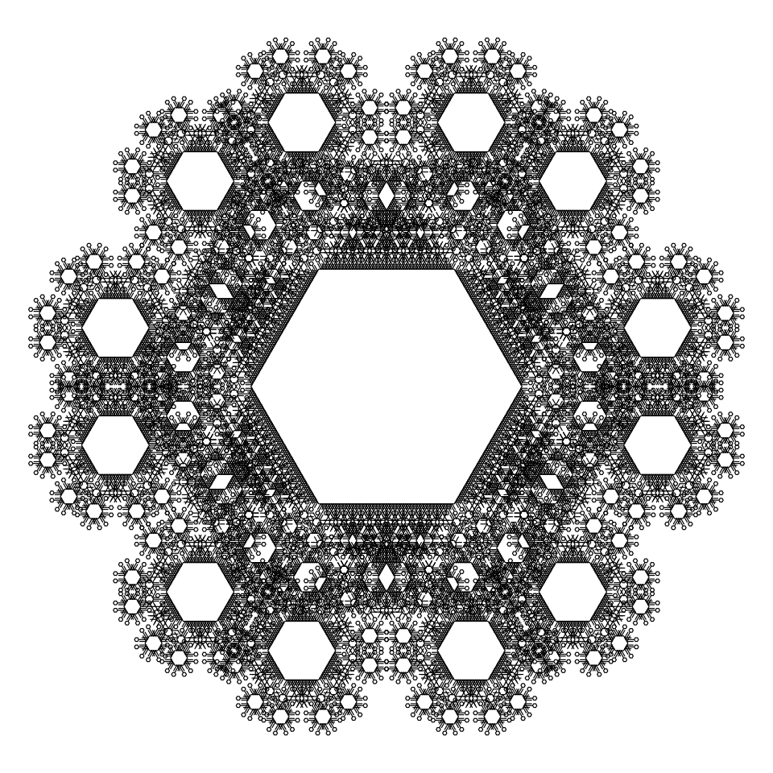

# Ballroom

This fancy tiled floor is great for hosting dances and ballets.

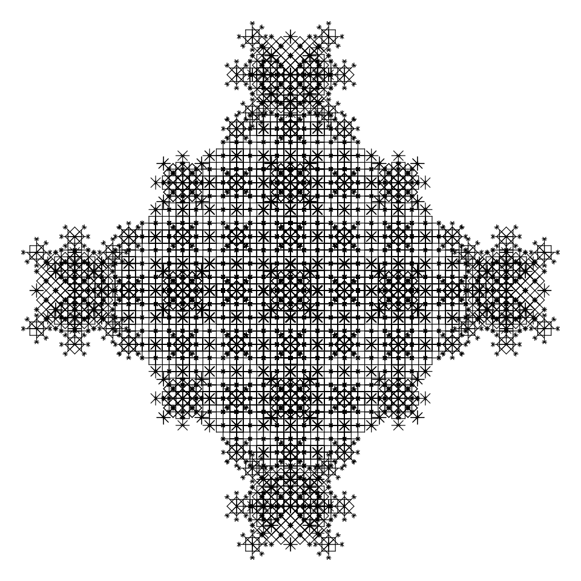

```
Angle = 45°
Start = A
Rules:
  A > [----AAB][--AAB][++AAB]AAB
  B > [-C][+C][--C][++C][---C][+++C]
  C > CAB
Number of recursions = 6
```

# 5-fold snowflake

All real snowflakes have 6-fold symmetry, but this one has 5-fold symmetry!

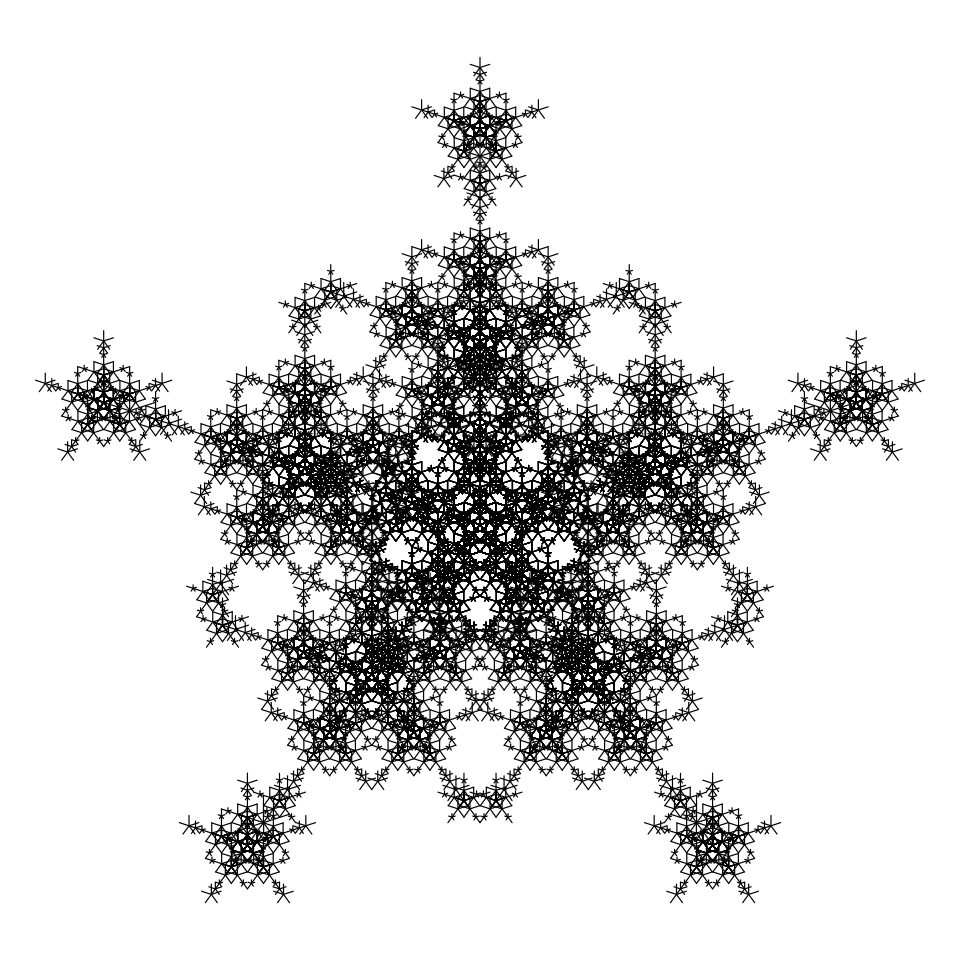

```
Angle = 72°
Start = A
Rules:
  A > [-AAB][--AAB][+AAB][++AAB]AAB
  B > [-C][+C][--C][++C]CA
  C > CC
Number of recursions = 5
```

# Spiraling hexagons

Twisting and turning, twisting a turning, smaller and smaller as they grow from each other, these hexagons surely spin a spiral at scales super and small.

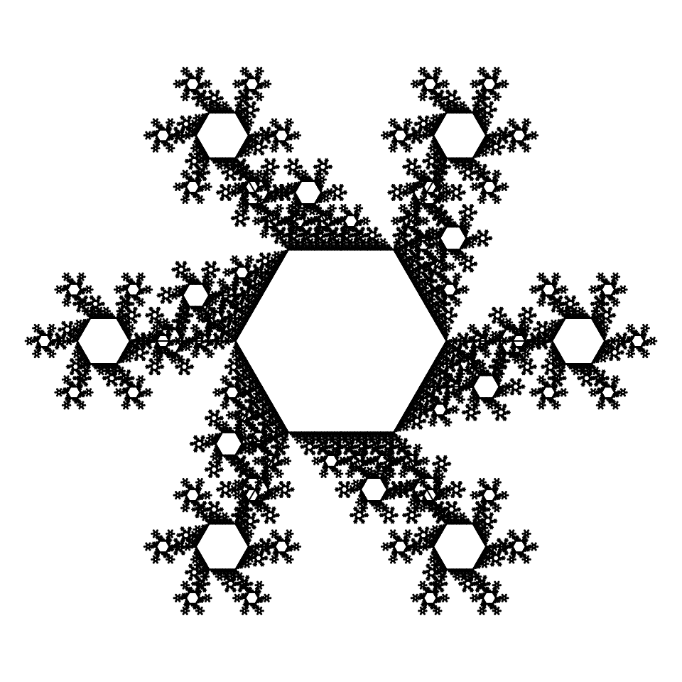

```
Angle = 60°
Start = a
Rules:
  a > -B+B+B+B+B+B
  B > BB[-CCa]
  C > CC
Number of recursions = 9
```

# Stars aligned

The stars are stacked into the shape of a star.

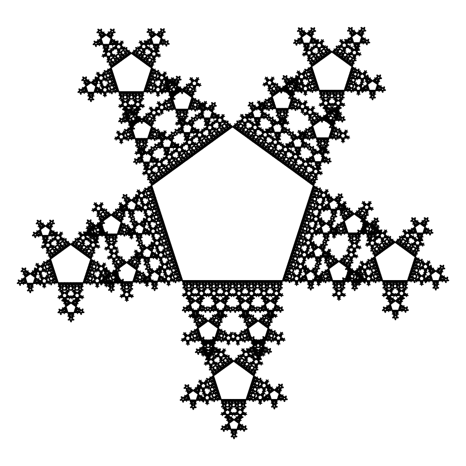

```
Angle = 72°
Start = A
Rules:
  A > B+B+B+B+B
  B > [-CCA]BB
  C > CC
Number of recursions = 9
```

# Fuzzy Fern

This strand of fuzzy fern hangs delicately.

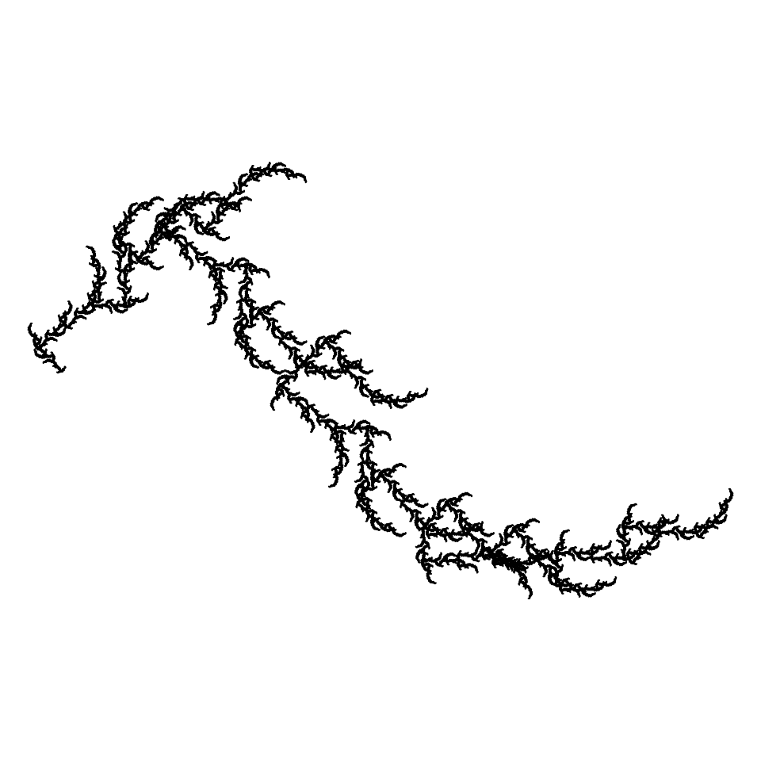

```
Angle = 45°
Start = A
Rules:
  A > +A-B-B[B]
  B > -B+A+A[A]
Number of recursions = 8
```

# Checkered Clouds

Variously sized clouds are puffing in an orderly array.

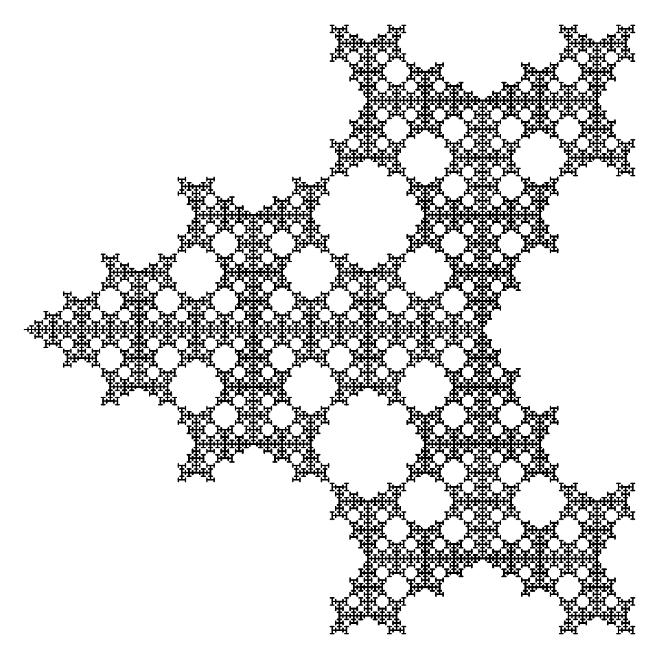

```
Angle = 90°
Start = A
Rules:
  A > AA[-A][+A]
Number of recursions = 8
```

# Wheels

This is reminiscent of nautical imagery, the helm (steering wheel) or a compass come to mind.

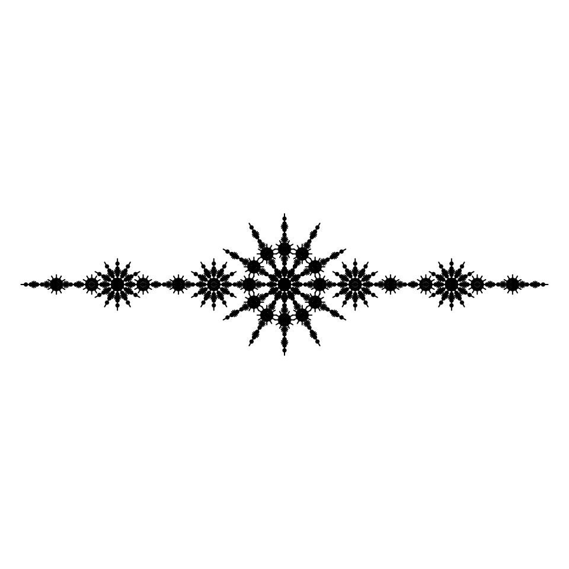

```
Angle = 30°
Start = A
Rules:
  A > AcbcA
  b > [+A][-A][++A][--A][+++A][---A][++++A][----A][+++++A][-----A]
  c > bAb
Number of recursions = 6
```

# Scary skull

An intimidating face menaces in the shadows.

[figure not shown]

```
Angle = 30°
Start = AB
Rules:
  A > B--B
  B > AA+++AA
Number of recursions = 12
```

# Mustache of mustaches

The handlebar mustache shape is composed of many little mustaches, all the way down.

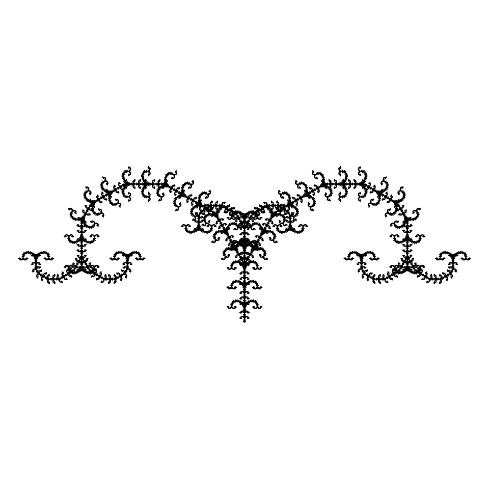

```
Angle = 30°
Start = x
Rules:
  x > FFF[+FFF+FFF+FF+FF+F+Fx][-FFF-FFF-FF-FF-F-Fx]Fx
  F > FFx
Number of recursions = 6
```

# Exploding Heart

The heart throbs faster and harder until it explodes in a splatter of broken pieces.

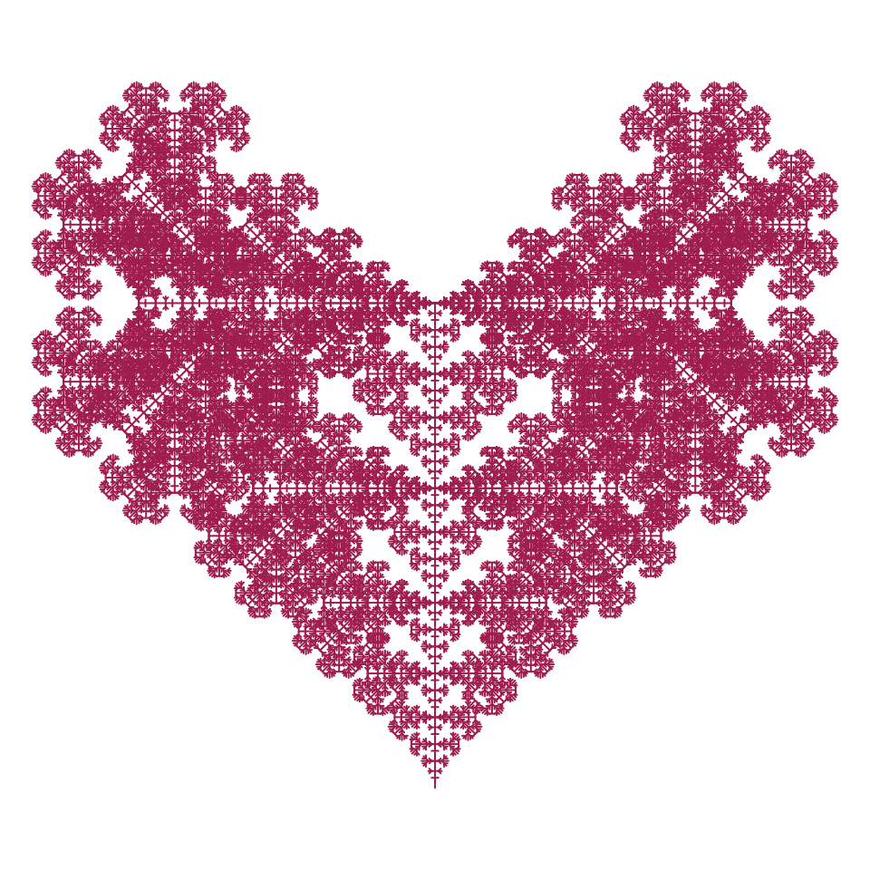

```
Angle = 45°
Start = A
Rules:
  A > AB
  B > A[++C][--C]
  C > C[+C][-C]A
Number of recursions = 10
```

# Barnsley fern example

I got this one from the [wikipedia on Lindenmayer Systems](https://en.wikipedia.org/wiki/L-system).

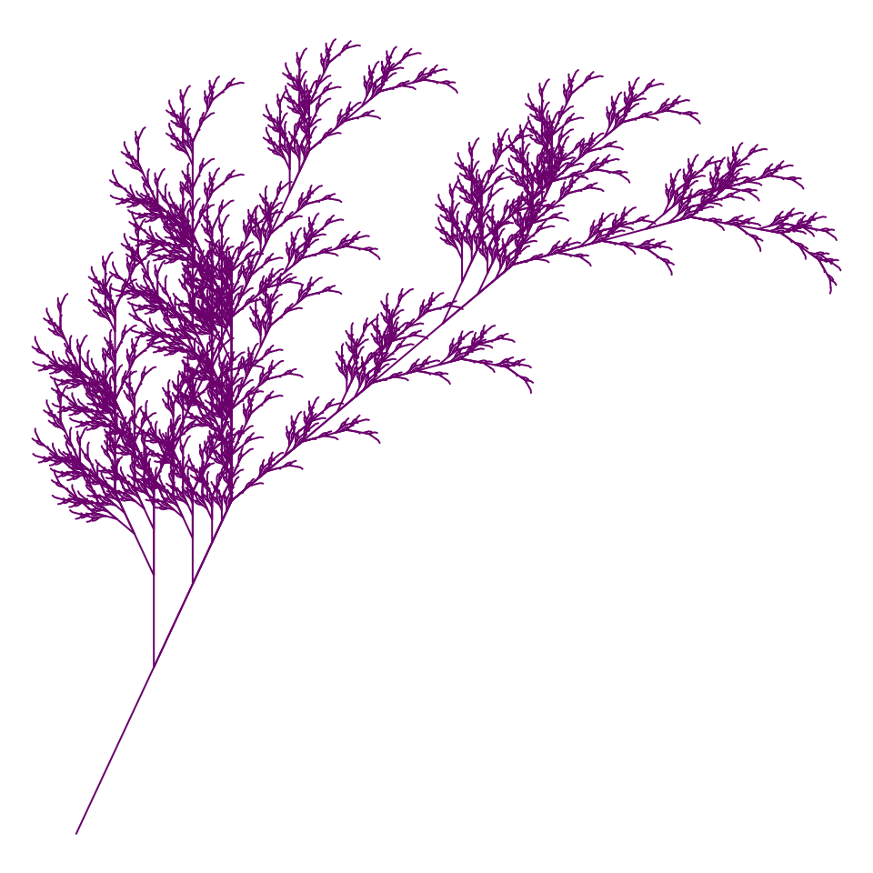

```
Angle = 25°
Start = -x
Rules:
  x > F+[[x]-x]-F[-Fx]+x
  F > FF
Number of recursions = 7
```

# Castle fortifications

I can imagine a castle with this footprint.

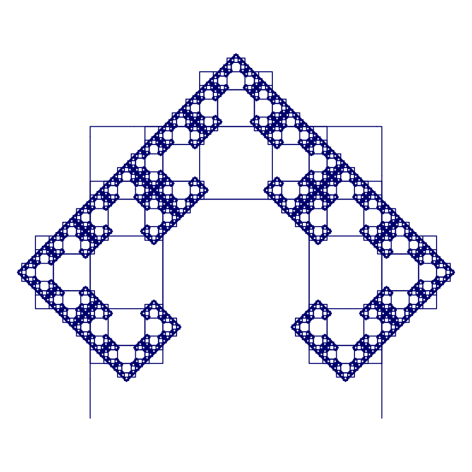

```
Angle = 90°
Start = b
Rules:
  A > AA
  b > AbA+AbA+AbA
Number of recursions = 9
```

# Broken Earth

This lush valley is filled with crags and lush forest fed by a convoluted river.

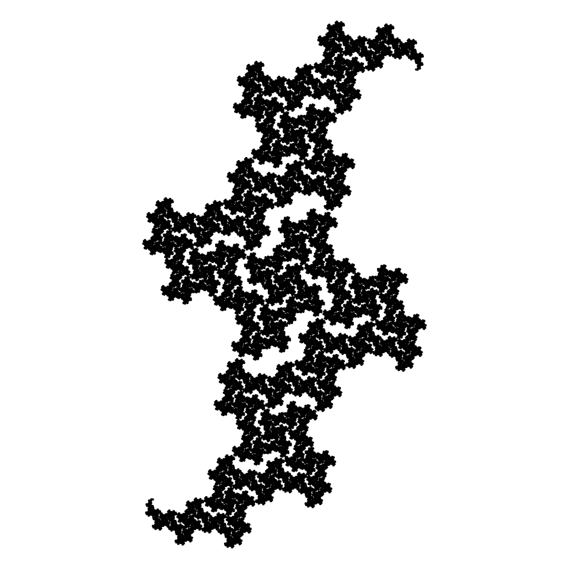

```
Angle = 115°
Start = A
Rules:
  A > A+A-A
Number of recursions = 11
```

# Robot God

The robot god glitches into form as it appears to its followers.

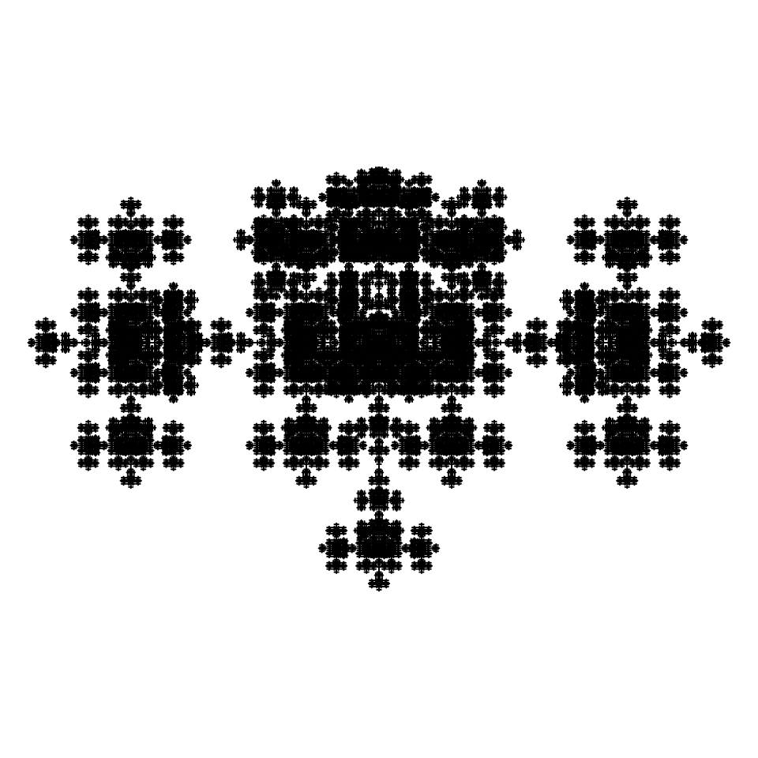

```
Angle = 90°
Start = A
Rules:
  A > A[+AA][-AA]B
  B > ABA
Number of recursions = 7
```

# Tree

What a beautiful tree with beautiful leaves.

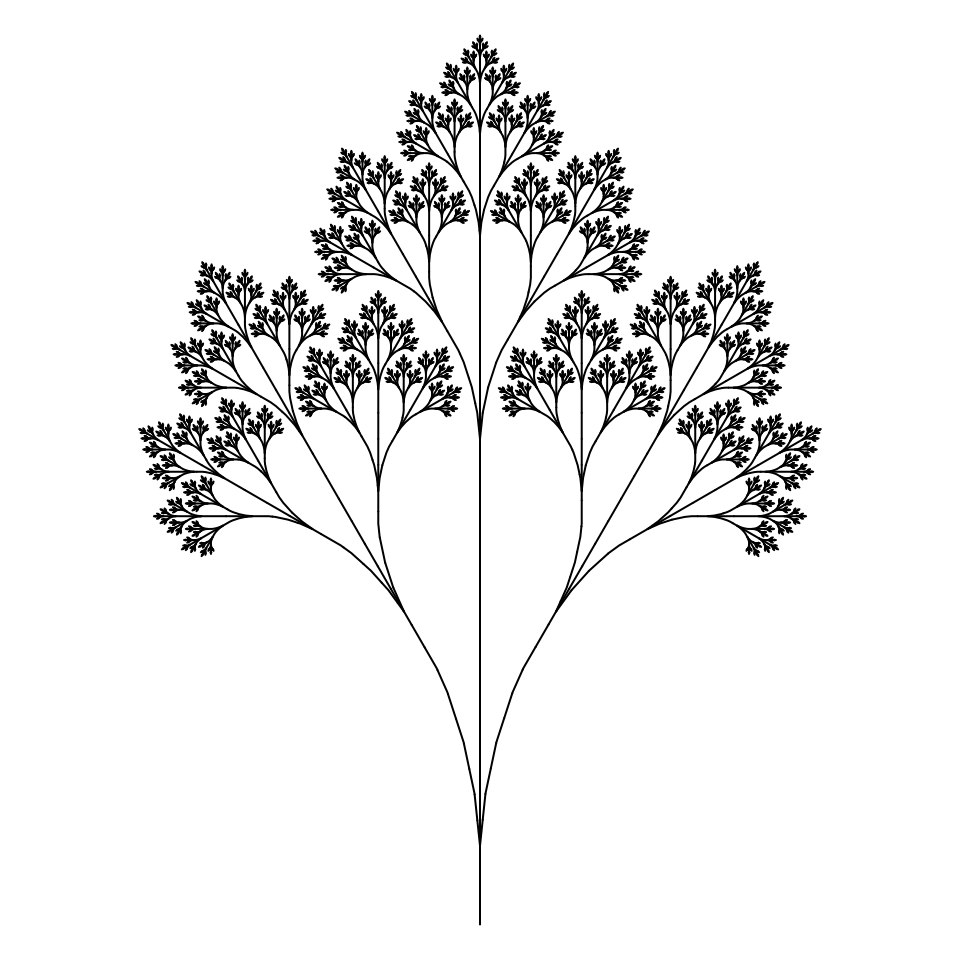

```
Angle = 6°
Start = x
Rules:
  x > FFF[+FF+FF+FF+F+Fx][-FF-FF-FF-F-Fx]FFFFFFFFFFFFFFx
  F > FF
Number of recursions = 8
```